# Propser Loan Data Exploratory Analysis by Sai Sri Lalitha Sravanthi Palleti

```
## [1] "C:/Users/Sravanthi/Documents"
```

# Introduction:

Prosper is the first peer-to-peer lending marketplace in the United States.Through Prosper, people can invest in each other in a way that is financially and socially rewarding.Prosper handles all loan servicing on behalf of the matched borrowers

and investors.I would like to analyze the loan data of and provide insights that

help understand relationships between different variables in the loan data

# Univariate Plots Section

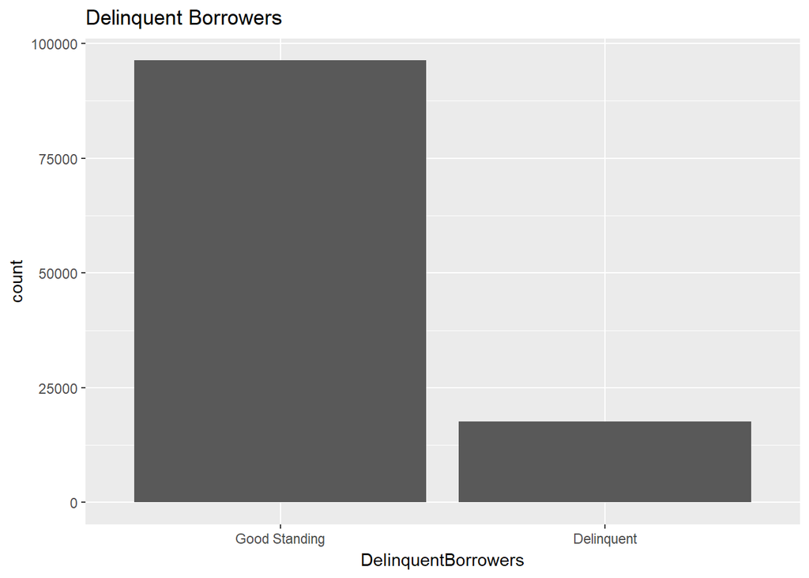

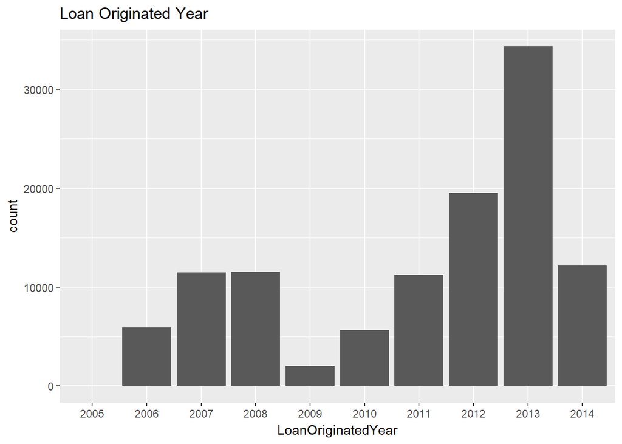

From the above plot more Loan are originated in 2013.Also there is a negative skewed distribution from year 2009 to 2013. I want to further investigate factors such as term of loan,Income Status, Occupation, Listing Category of the borrower

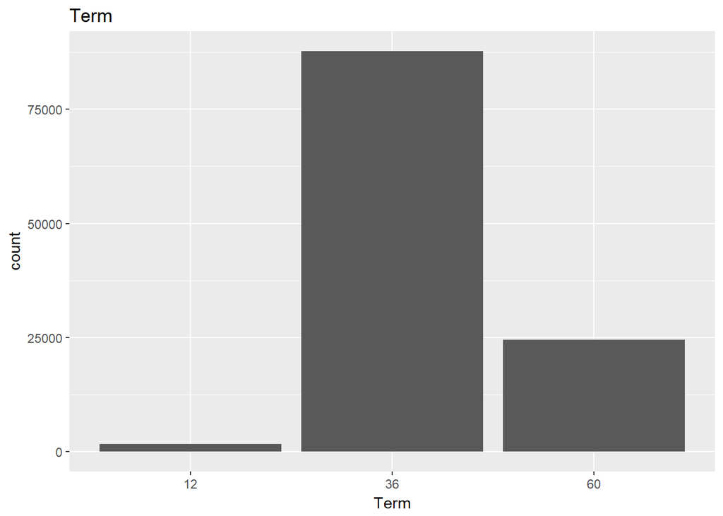

From the above plot I have learned that most loans are 36 month period .Lets see teh plot of Loan Amount

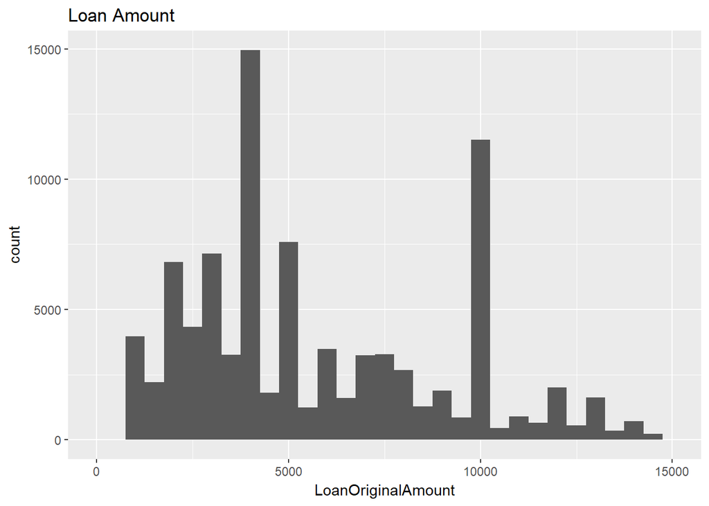

Loan Amount has high peak around 3000$ - 4000$.Lets see for which loan category are they taking this amount to get more clarity around here

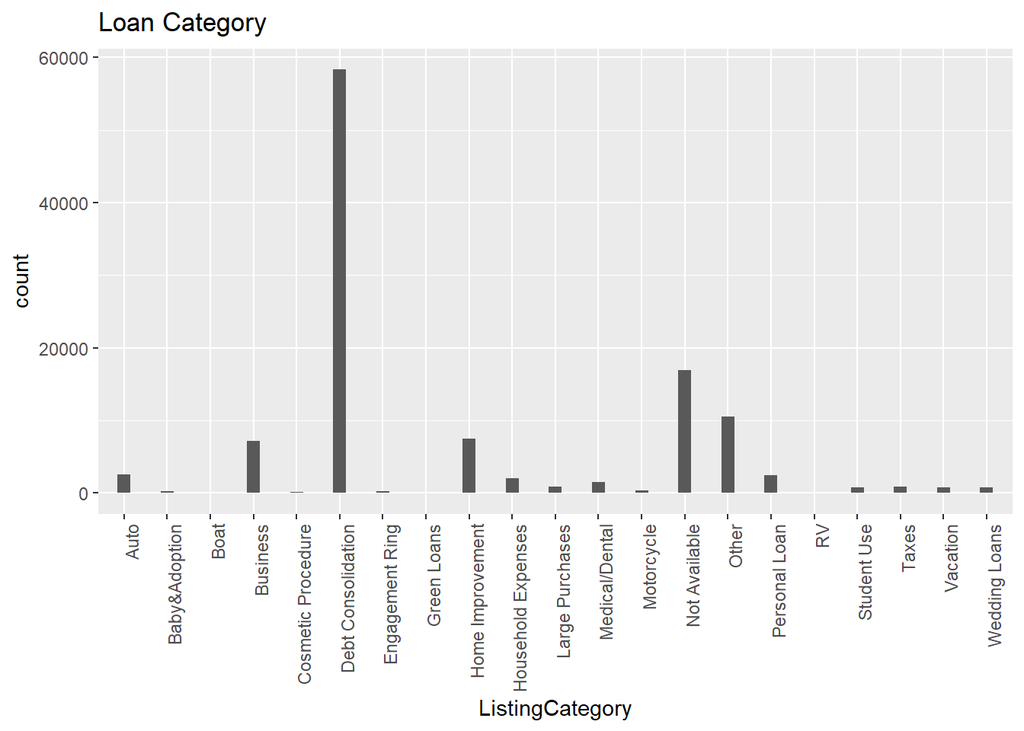

Debt Consolidation has the highest majority.Lets see the Income range of borrowers to investigate the Reason for debt

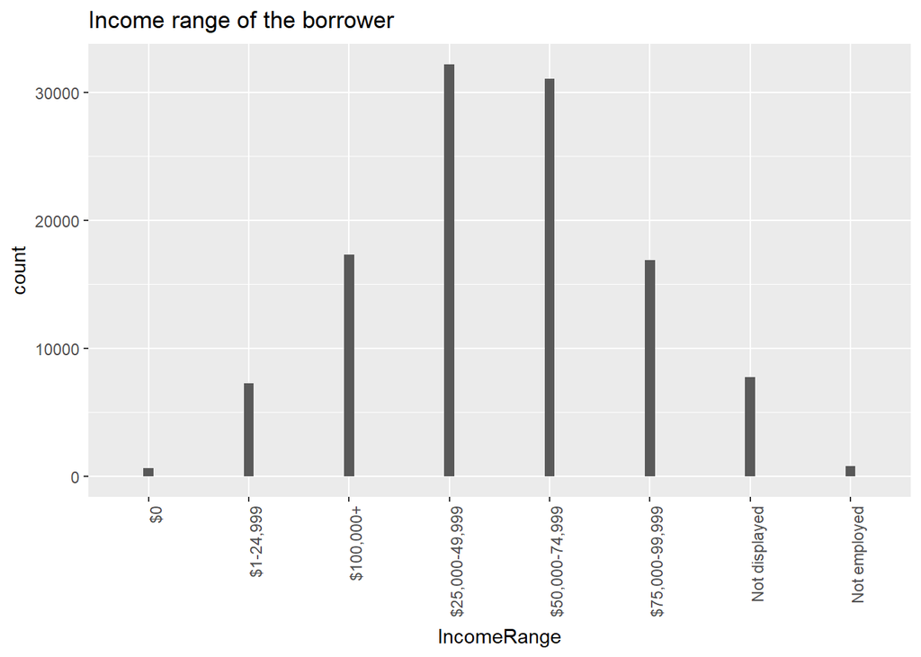

The above plot shows that the borrowers are more in the Income Range 25,000 - 49,999$ ,lets also see teh employment status to see if all debt consolidations are coming from employed borrowers or not

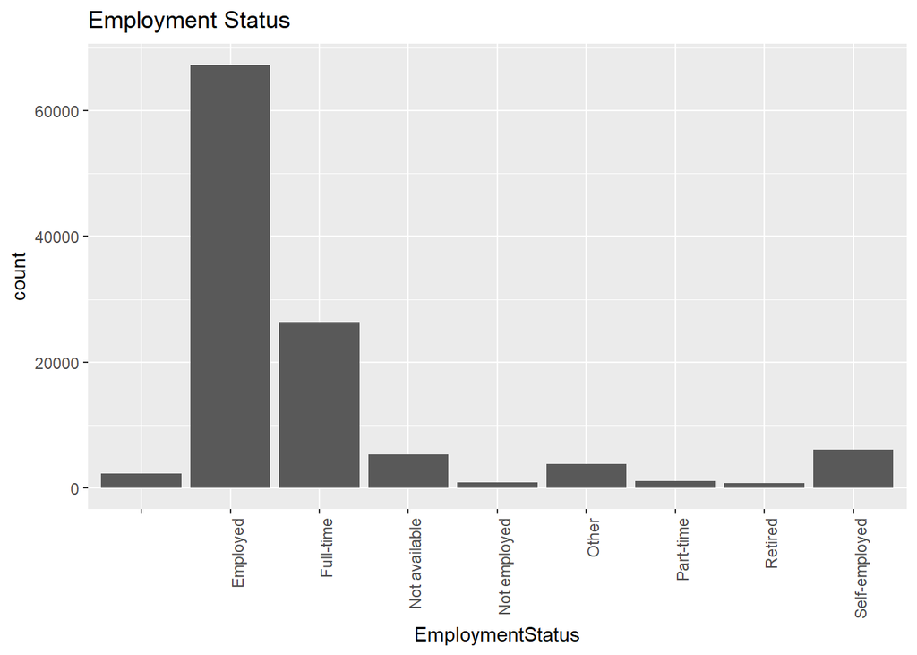

Surprisingly there are more number of borrowers who are employed.Lets also see the Bank Card Utilization to understand the reason for Debt of employed borrowers

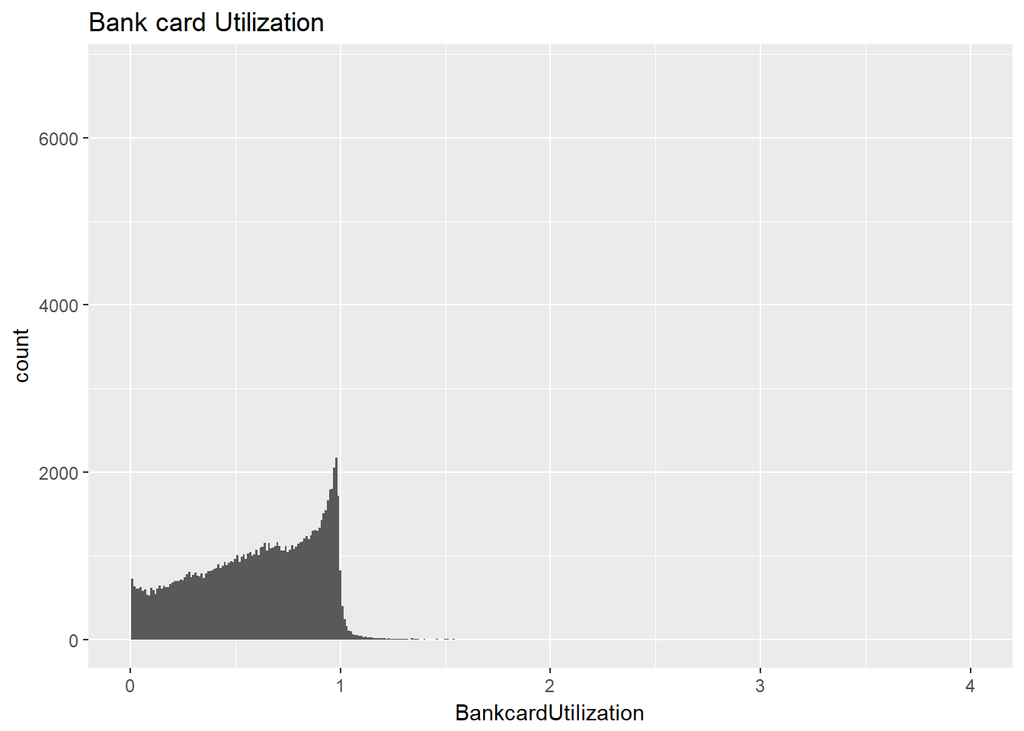

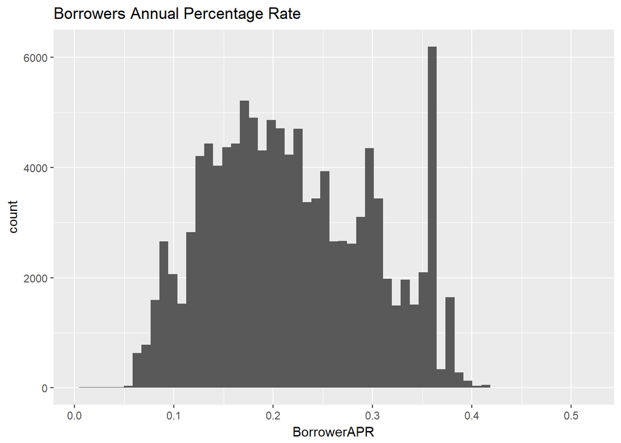

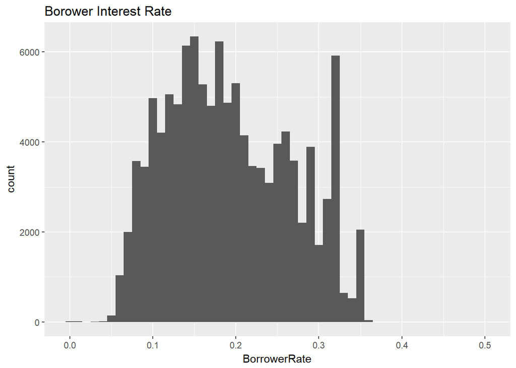

```
##    Min. 1st Qu.  Median    Mean 3rd Qu.    Max.
##  0.0000  0.1340  0.1840  0.1928  0.2500  0.4975
```

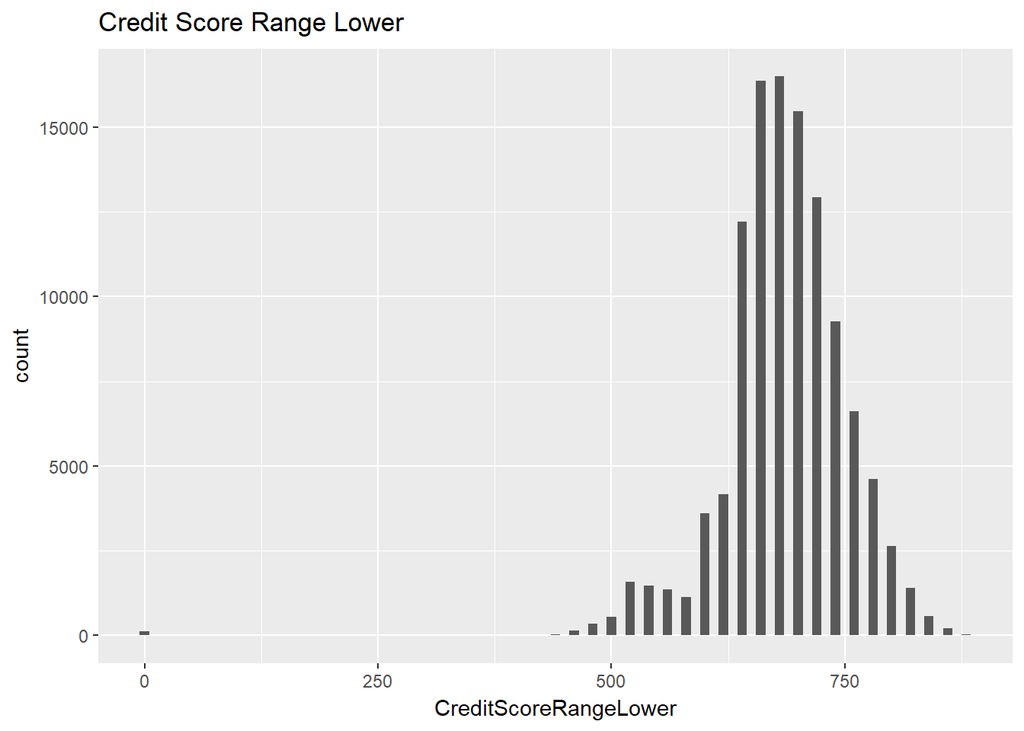

Credit score lower Range plot shows a normal distribution from creditscore 500 to 800.Before considering this a factor for delinquency , lets also see the plot of Upper range of Credit Score

```
##    Min. 1st Qu.  Median    Mean 3rd Qu.    Max.    NA's
##     0.0   660.0   680.0   685.6   720.0   880.0     591
```

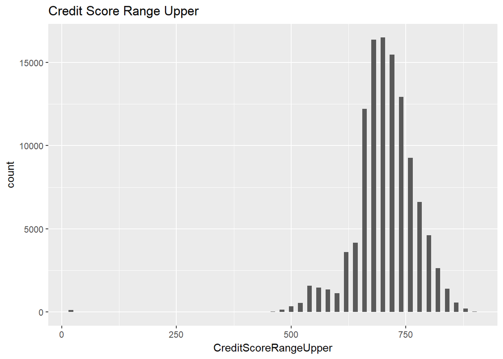

Upper range of credit Score also has the same distribution as Lower range of credit Score. The highest peak is between 650 and 750. So am assuming delinquencies will be higher at this range of Credit score .Lets see the actual results in Bivariate plots

```
##    Min. 1st Qu.  Median    Mean 3rd Qu.    Max.    NA's
##    19.0   679.0   699.0   704.6   739.0   899.0     591
```

# Univariate Analysis

### What is the structure of your dataset?

There are 113937 observations in the Loan dataset with 81 features. I have subsetted the data and taken only 24 variables for analysis

### What is/are the main feature(s) of interest in your dataset?

After reviewing the long list of variables, and thinking of all of the different paths of investigation, I’ve decided to narrow my focus of investigation around deliquencies and their correlations

The main features for this exploration are: - Term: The length of the loan expressed in months - Loan Status: Current Status of the Loan - Cancelled - Charged off - Completed - Defaulted - FinalPaymentInProgress - Past Due

- Borrower State: The two letter abbreviation of the state of the address of the borrower at the time the Listing was created.
- Listing Category: The category of the listing that the borrower selected when posting their listing 0 - Not Available 1 - Debt Consolidation 2 - Home Improvement 3 - Business 4 - Personal Loan 5 - Student Use 6 - Auto 7- Other 8 - Baby&Adoption 9 - Boat 10 - Cosmetic Procedure 11 - Engagement Ring 12 - Green Loans 13 - Household Expenses 14 - Large Purchases 15 - Medical/Dental 16 - Motorcycle 17 - RV 18 - Taxes 19 - Vacation 20 - Wedding Loans
- Credit Score Range Lower: The lower value representing the range of the borrower’s credit score as provided by a consumer credit rating agency
- Credit Score Range Upper: The upper value representing the range of the borrower’s credit score as provided by a consumer credit rating agency
- Bankcard Utilization: The percentage of available revolving credit that is utilized at the time the credit profile was pulled
- Income Range: The income range of the borrower at the time the listing was created
- Loan Original Amount: The origination amount of the loan
- Investors: The number of investors that funded the loan

### What other features in the dataset do you think will help support your investigation into your feature(s) of interest?

These features help to contribute to deeper dives and identification of possible trends: - Listing Creation Date: The date the listing was created - Occupation: The Occupation selected by the Borrower at the time they created the listing - IsBorrowerHomeOwner: A Borrower will be classified as a homowner if they have a mortgage on their credit profile or provide documentation confirming they are a homeowner - BorrowerAPR: The Borrower’s Annual Percentage Rate (APR) for the loan - BorrowerRate: The Borrower’s interest rate for this loan - Recommendations: Number of recommendations the borrower had at the time the listing was created - TotalProsperLoans: Number of Prosper loans the borrower at the time they created this listing. This value will be null if the borrower had no prior loans - DebttoIncomeRatio: The debt to income ratio of the borrower at the time the credit profile was pulled - StatedMonthlyIncome: The monthly income the borrower stated at the time the listing was created

### Did you create any new variables from existing variables in the dataset?

Yes,I have created three new variables: - Listing Category from Listing Category Numeric - LoanOriginatedYear from LoanOriginatedDate - Delinquent Borrowers from Loan Status

### Of the features you investigated, were there any unusual distributions? Did you perform any operations on the data to tidy, adjust, or change the form of the data? If so, why did you do this?

I have performed data type conversions on date columns in the data to apply date functions such as extracting days, months or years on the data

# Bivariate Plots Section

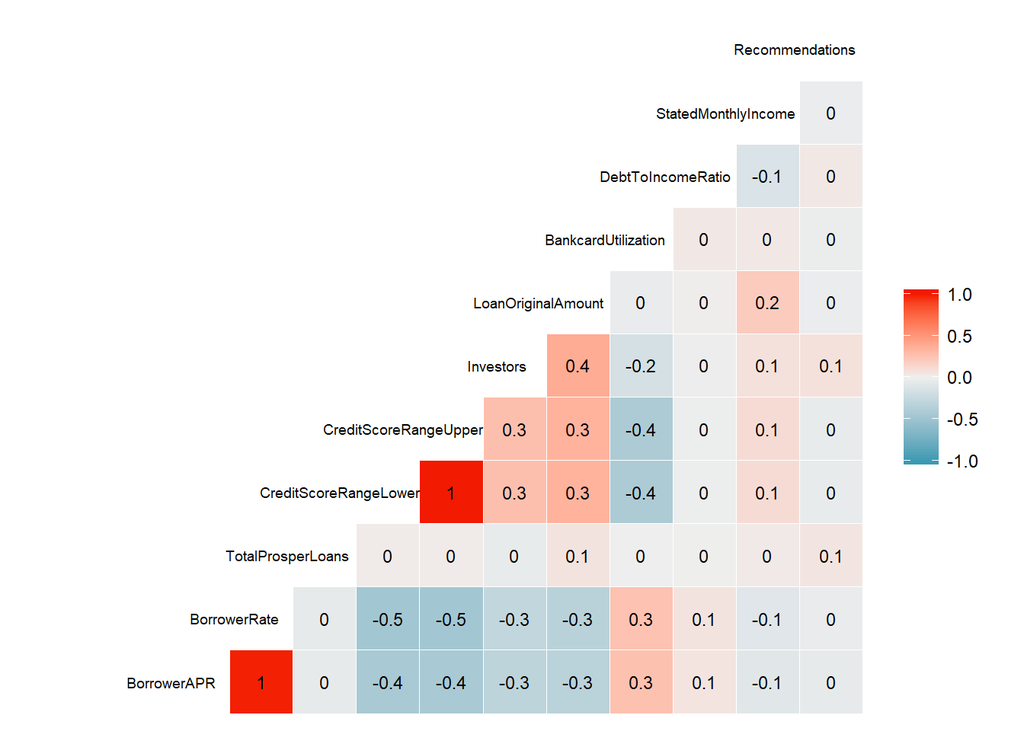

I want to look closer at scatter plots involving Delinquent Borrowers and some other variables like Loan Amount, Loan Originated Year,Listing category,Debtto IncomeRatio,Bank CardUtilization,Loan Status

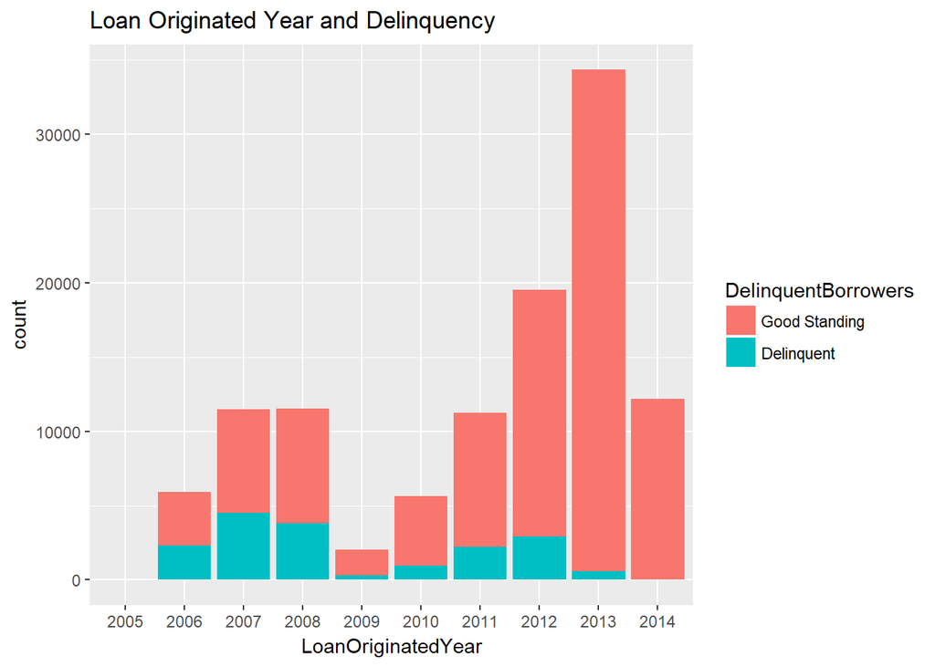

Surprisingly, from the above plot more delinquencies happened in 2007, 2008 .I expected more delinquencies in 2013 , as it has the highest loans originated.May be 2007 an d2008 are the financial crisis years. I want to further investigate like in what factors led to delinquncy such as term of loan, Income Status, Occupation, Listing Category of the borrower

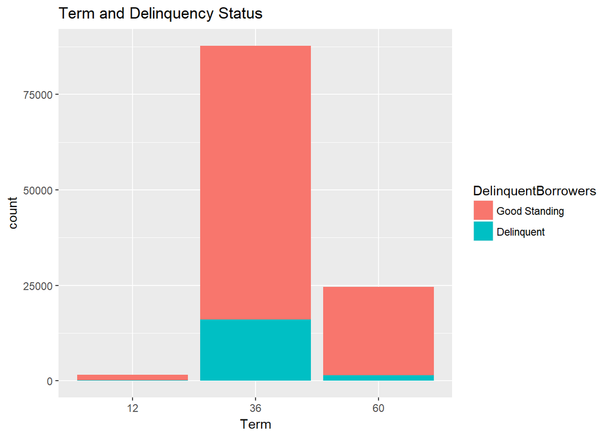

As expected ,From the above plot delinquencies are high in the 36 month term.Lets see the loan amount range

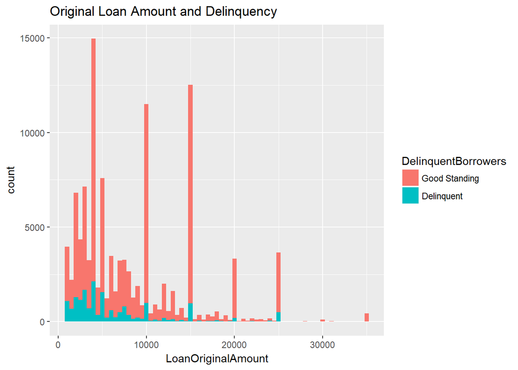

Loan Amount has high peak around 4000$ and also most delinqunecies for that loan amount.Lets see for which loan category are they taking this amount to get more clarity around here

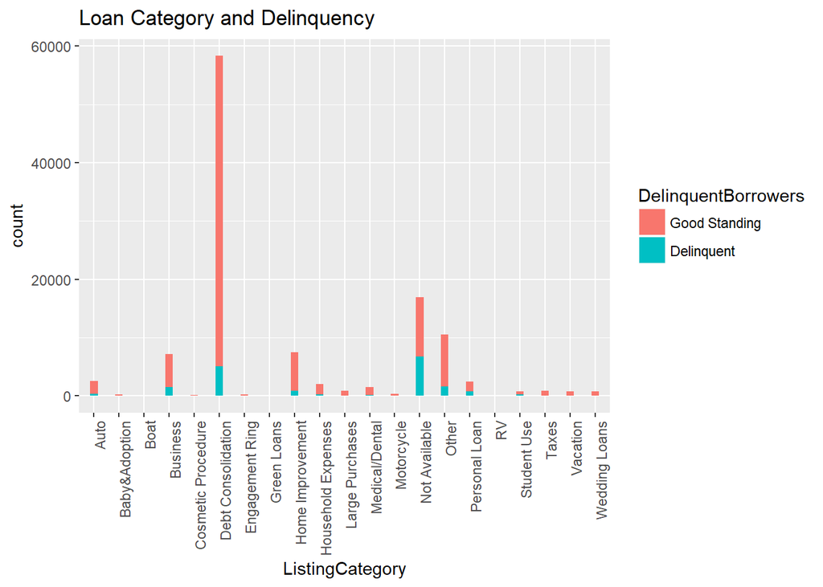

Surprisingly , NOt available lOan Category has highets delinquency than Debt Consolidation.Here we did not get any clue for Delinquency rate.Lets see Income range of borrowers

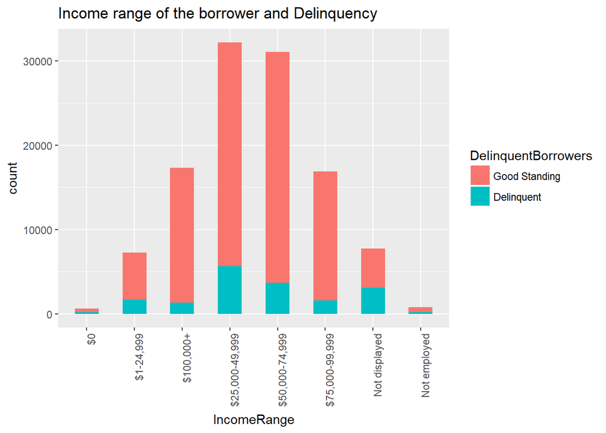

The above plot shows that the borrowers are more in the Income Range 25,000 - 49,999$ and delinquency is also high in this range, lets also see the employment status to see if all delinquencies are coming from employed borrowers or not

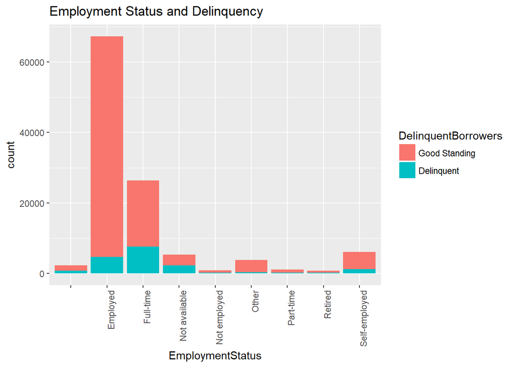

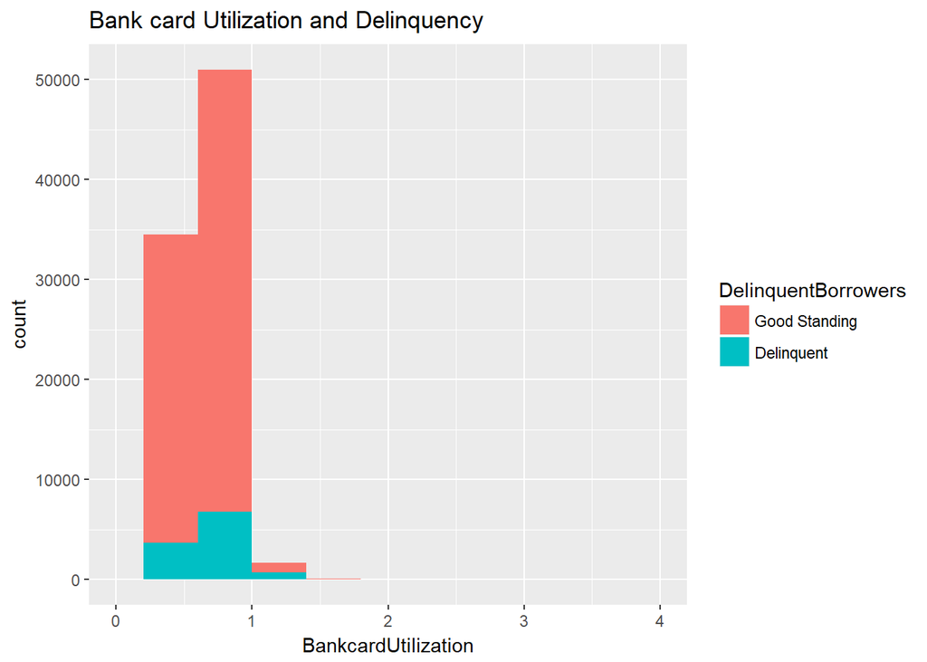

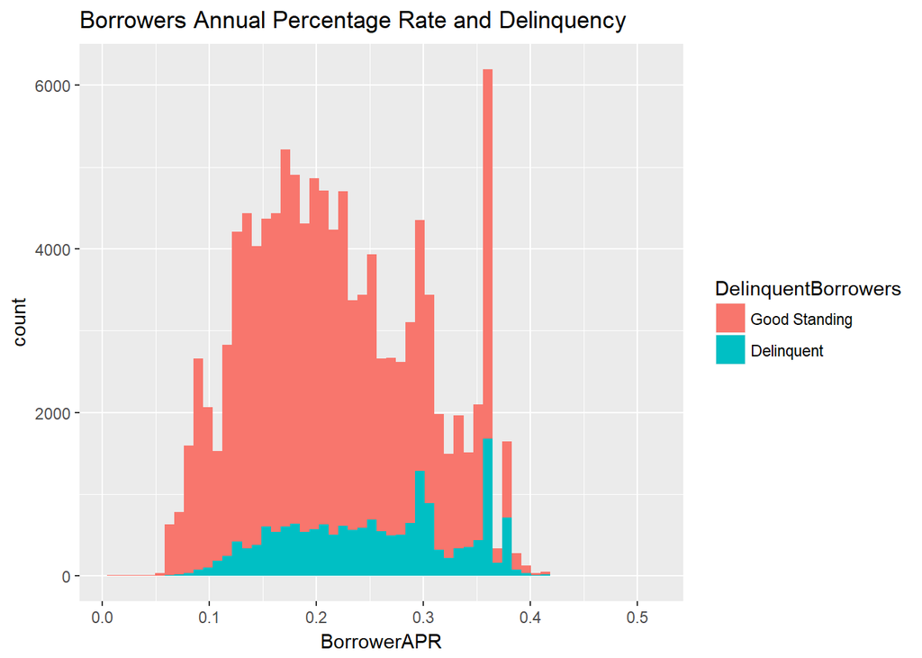

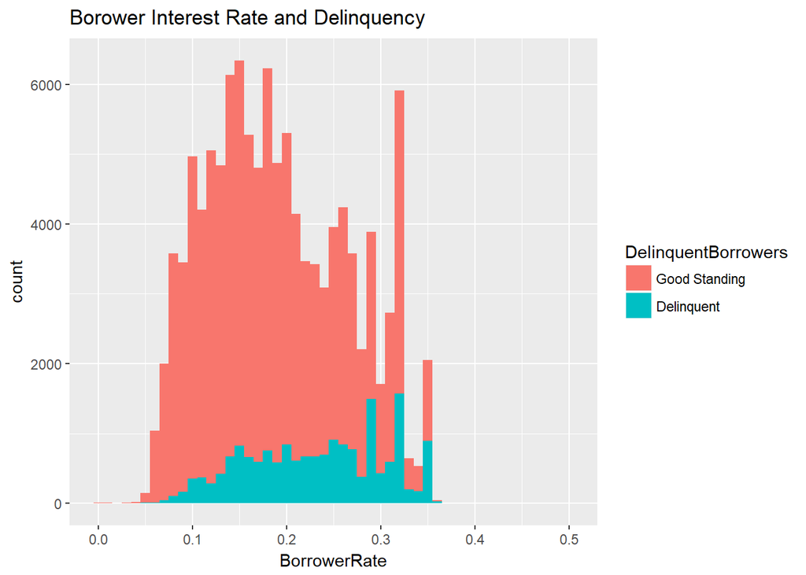

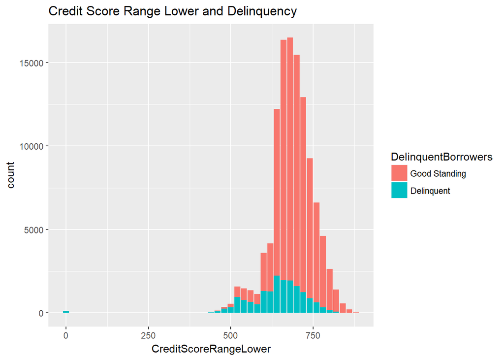

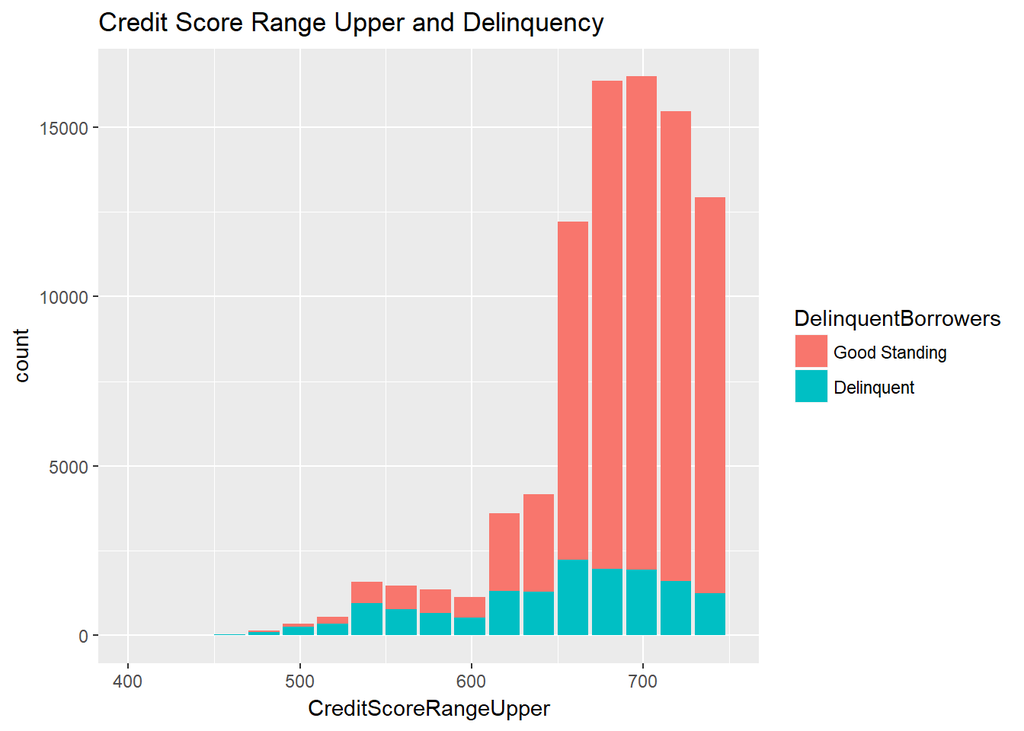

we know from univariate plots that Credit score has normal distribution in the range 500-700 and highest credt score in the range 650 - 700,the delinquencies are high in the same range, this is expected.Lets also see the relations between these factors Loan year and LOanAmount, Loan Category and Loan amount and Term Loan Amount, MOnthly Income, Bank Card Utilizaion , Debt to Income Ratio, Interest rate ,credit score and Investors

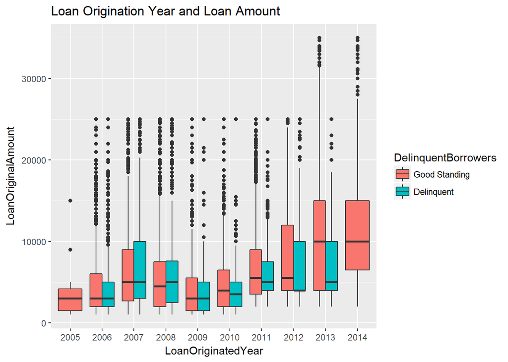

The highest mean of Loan amount is shown in the years 2013 and 2014.MOre delinquencies are shown in 2007, this might be financial crisis year

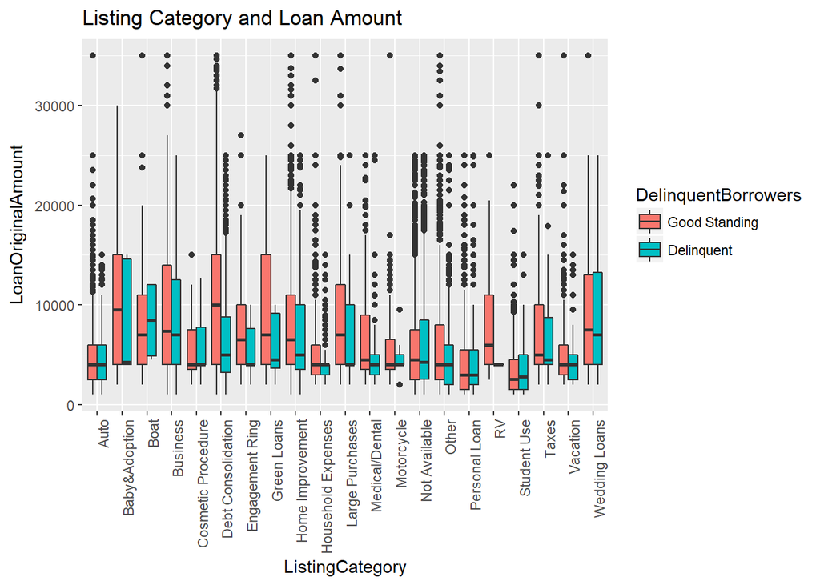

Debt Consolidation and Baby adoption has highest mean of Loans.Lets see at which more LoanAmount is Taken

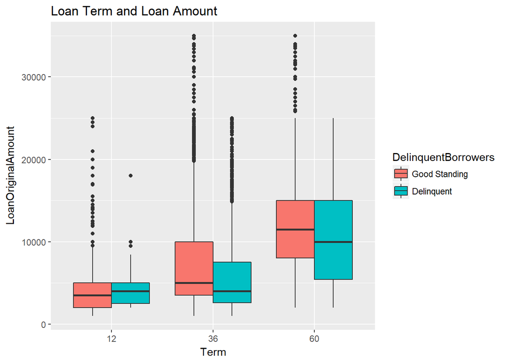

By obersving the above 3 boxplots for the 3 terms ,surprisingly the 60 month term has highest mean of Loan amount. This is quite surprising because in univariate analysis , the term 36 month plot has around 80k borrowers .This considering our previous plot where only approx. 25k borrowers used 60 month term loans in comparison to approx. 80k borrowers who used 36 month terms

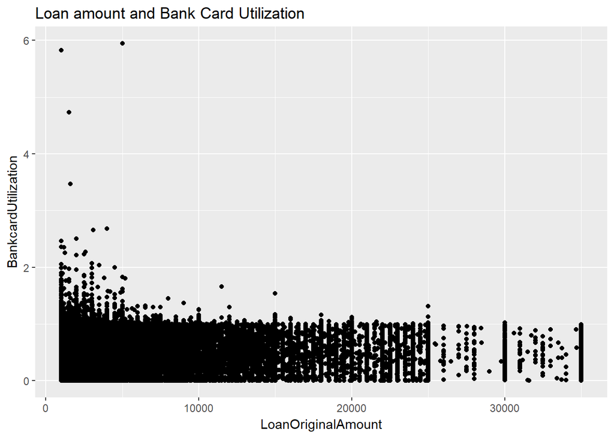

we see a high volume cluster of loans under $10,000 with borrowers close to 100% bankcard utilization.This is quite surprising

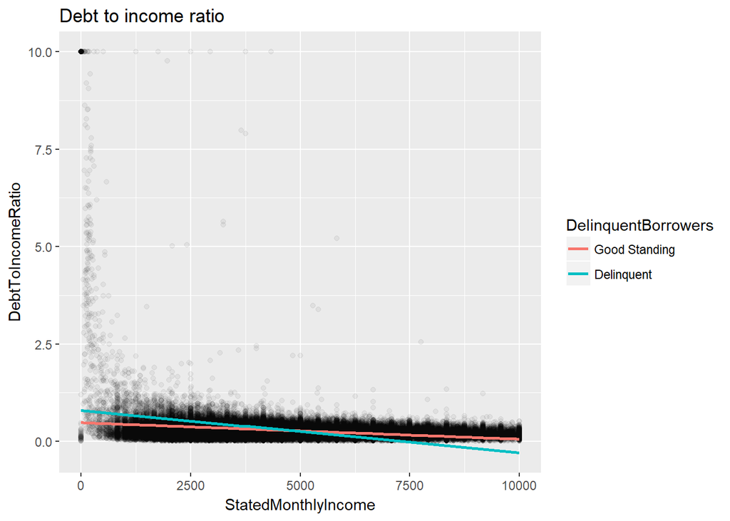

The plot suggests a negative correlation between monthly income and debt-to-income ratio

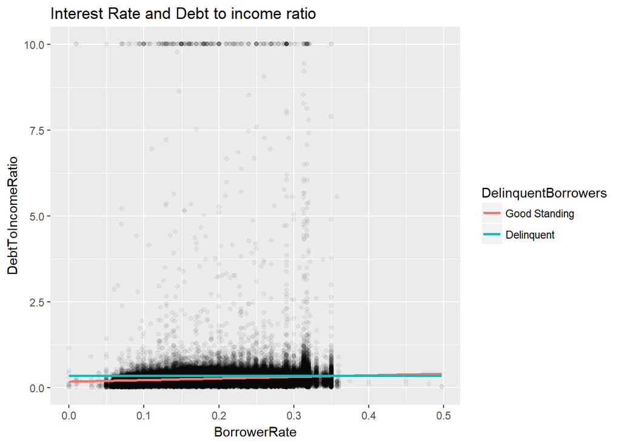

The relationship between a borrower’s interest rate (BorrowerRate) and their debt ratio (DebtToIncomeRatio) was expected to be a positive correlation. I expected borrowers with high debt-to-income ratios would automatically receive higher interest rates on their loans. However, based on the above scatterplot, there seems to be no trend and a weak positive correlation between these two variables

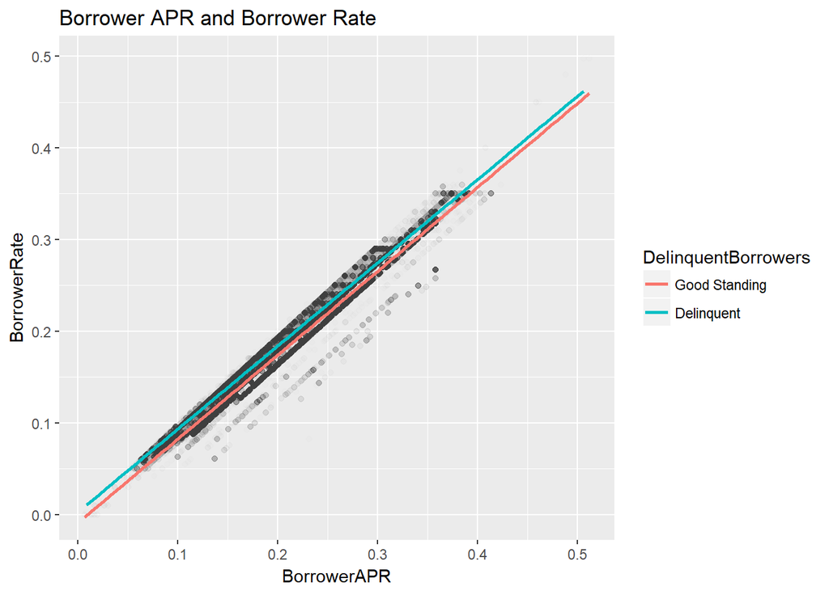

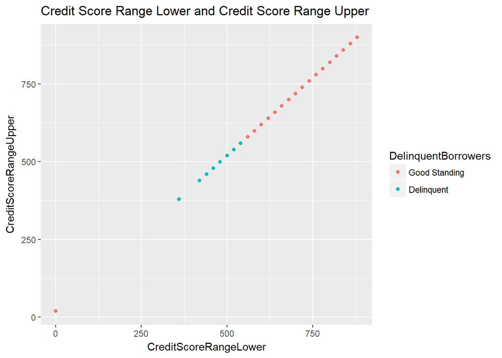